# Marginal/Interaction scans using weighted linear models

Andrey Ziyatdinov

2017-06-05

# 1 About

We have 37K (clean and long) local ancestry segments to test in data coming from African-Americans. These data have some structure due to medical centers and distant genetic relationships (ancestry), explaining a relatively small portion of variance (~5% and ~1%).

- Including an additional random term `(1|ccenters)` in the framework of Linear Mixed Models (LMMs) slightly reduced the inflation factor from 1.19 to 1.16 (`FEV1pp` phenotype).
  - The drawback was a slow computation, so we could not apply LMMs to all phenotypes.
- Including PCs (estimated either from genotypes or ancestry) did not help to fix the problem of inflation.
  - We know that PC1 = global ancestry and the later is presented in the association model, so including PC1 is ambiguous. We also know that PC1 explains the most part of the variance (60%), while the next component PC2 - 3%.

In this report, we will extend the association model one step further by including the genetic random effect. In particular, our analysis has several parts:

- Figure out the covariance matrix in multivariate normal (MVN) distribution of association test statistics.
  - GARM (includes global ancestry) or ARM (free of global ancestry)?
- Add the genetic random effect (ancestry), although its contribution to variance is expected to be small.
  - (Zaitlen et al. 2014) showed that 80% heritability estimated using genotypes = 13% heritability estimated using ancestry (Fst = 0.5)
- Add additional random effect ($K_d$) for the interaction analysis (Sul et al. 2016)

We still have other things to implement in the future:

- Test statistics are still correlated, so we need to implement permutation tests as in (Conneely and Boehnke 2007) and in efficient way.
  - It is a computationally demanding task: 10K permutations, 3K individuals, 37K ancestry segments.

# 2 GARM or ARM

- GARM computed on raw ancestry segments data
- ARM:
  - global ancestry is projected out from ancestry segments data
  - ARM is computed

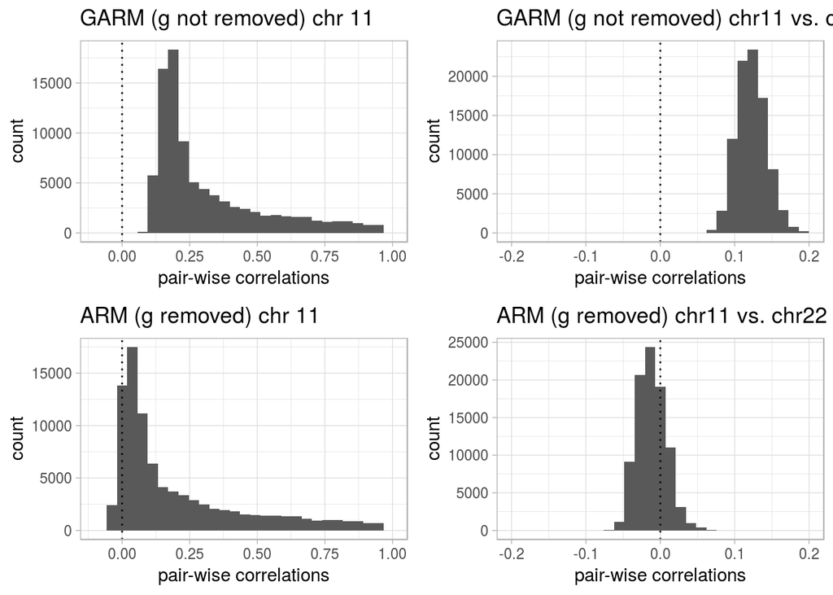

- 300 random ancestry long segments selected from Chr 11 and 22
- we converted covariance to correlation matrices for a fair pair-wise comparison.

## 2.1 Model of interest

1. `y ~ acs_global + acs_local + (1|sid)` with GARM
2. `y ~ acs_global + acs_local + (1|sid)` with ARM

As `acs_global` is PC1 of GARM, the distribution of association statistics is MVN(0, ARM).

We still need to prove this statement in experiments.

# 3 Model specification

- We considered only long segments (working on all segments is currently computationally hard)
- We used ARM (not GARM) as $K$ matrix in the genetic random effect, because `acs_global` is a covariate in association models.

## 3.1 Previous scan

- Marginal model: `FEV1_FVC_utah ~ ... + SmokCigNow + acs_global + acs_local + error`
- Interactgion model: `FEV1_FVC_utah ~ ... + SmokCigNow + acs_global + acs_local + acs_local:SmokCigNow + error`

Reports

- Report 5 [GxA results on versions 0 and 1](https://hemostat.github.io/Public/copdgene/reports/05-results-ver-0-1/05-results-ver-0-1.html)
- Report 7 [QQ-plots on ancestry-based GWAS](https://hemostat.github.io/Public/copdgene/reports/07-inflation/07-inflation.html)

## 3.2 Current scan

Step (1) The baseline (liner-mixed) model before testing for local ancestry association:

- Marginal model: `FEV1_FVC_utah ~ ... + SmokCigNow + acs_global + (1|ccenter) + (1|sid) + error`
- Interaction model: `FEV1_FVC_utah ~ ... + SmokCigNow + acs_global + (1|ccenter) + (1|sid) + (1|esid) + error`

According to notation in (Sul et al. 2016):

- Marginal model: $var(y) = \sigma^2_c \Sigma_{centers} + \sigma^2_g K + \sigma^2_e I$
- Interaction model:
  - (marginal varcov) $var(y) = \sigma^2_c \Sigma_{centers} + \sigma^2_g K + \sigma^2_e I$
  - (interaction varcov) $var(y) = \sigma^2_c \Sigma_{centers} + \sigma^2_g K + \sigma^2_{ge} K_d + \sigma^2_e I$

Step (2) The association (weigthed linear) model, in which the variance-covariance matrix from model (1) is used.

- Marginal model: `FEV1_FVC_utah ~ ... + SmokCigNow + acs_global + acs_global + weighted_error`
- Interaction model: `FEV1_FVC_utah ~ ... + SmokCigNow + acs_global + acs_local + acs_global::SmokCigNow + acs_local:SmokCigNow + weighted_error`

## 3.3 Covariates

Covariates used as fixed effects:

| trait | cov |
| --- | --- |
| FEV1_FVC_utah | Age_Enroll, Age_Enroll2, gender, SmokCigNow, ATS_PackYears, acs_global |
| FEV1pp_utah | Age_Enroll, gender, SmokCigNow, ATS_PackYears, acs_global |
| FEV1_utah | Age_Enroll, Age_Enroll2, gender, Height_CM, SmokCigNow, ATS_PackYears, acs_global |
| FVCpp_utah | Age_Enroll, gender, SmokCigNow, ATS_PackYears, acs_global |
| FVC_utah | Age_Enroll, Age_Enroll2, gender, Height_CM, SmokCigNow, ATS_PackYears, acs_global |
| log_pctEmph_Slicer | Age_Enroll, gender, SmokCigNow, ATS_PackYears, acs_global |
| TLCpp_race_adjusted | Age_Enroll, gender, SmokCigNow, ATS_PackYears, acs_global |
| finalGold_bin | Age_Enroll, gender, SmokCigNow, ATS_PackYears, acs_global |

## 3.4 Grouping variables

Grouping variables used as random effects:

| trait | gr |
| --- | --- |
| FEV1_FVC_utah | ccenter |
| FEV1pp_utah | ccenter |
| FEV1_utah | ccenter |
| FVCpp_utah | ccenter |
| FVC_utah | ccenter |
| log_pctEmph_Slicer | ccenter, scanner_gr |
| TLCpp_race_adjusted | ccenter |
| finalGold_bin | ccenter |

## 3.5 Explained variance (marginal)

| trait | var_prop_sid | var_prop_ccenter | var_prop_Residual |
| --- | --- | --- | --- |
| FEV1_FVC_utah | 0.01124 | 0.05235 | 0.9364 |
| FEV1pp_utah | 0.01092 | 0.05803 | 0.9311 |
| FEV1_utah | 0.01045 | 0.04712 | 0.9424 |
| FVCpp_utah | 0.005956 | 0.03475 | 0.9593 |
| FVC_utah | 0.007152 | 0.03328 | 0.9596 |
| log_pctEmph_Slicer | 0.01168 | 0.03614 | 0.7635 |
| TLCpp_race_adjusted | 0.01704 | 0.03315 | 0.9498 |

## 3.6 Explained variance (interaction)

| trait | var_prop_esid | var_prop_sid | var_prop_ccenter | var_prop_Residual |
| --- | --- | --- | --- | --- |
| FEV1_FVC_utah | 0.005045 | 0.01564 | 0.05188 | 0.9274 |
| FEV1pp_utah | 0 | 0.02614 | 0.05702 | 0.9168 |
| FEV1_utah | 0 | 0.02111 | 0.04676 | 0.9321 |
| FVCpp_utah | 0 | 0.01975 | 0.03405 | 0.9462 |

# 4 Marginal scan in `FEV1_FVC_utah`

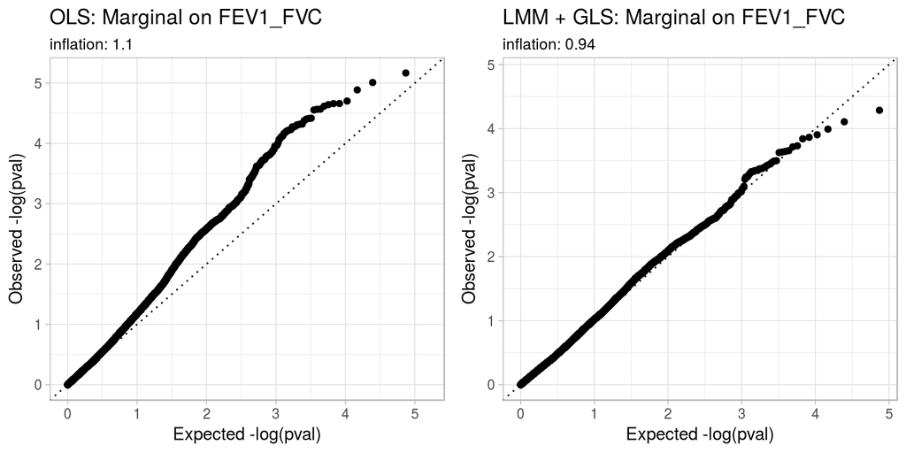

The proportions of variances estimated for `FEV1_FVC_utah` trait:

$var(y) = 0.052 \Sigma_{centers} + 0.011 \sigma^2_g K + 0.936 I$

### 4.0.1 Top singals

| acs | pval0 | pval | pval0_bonf | pval_bonf |
| --- | --- | --- | --- | --- |
| chr12acs104145 | 6.811886e-06 | 5.169820e-05 | 0.2520398 | 1 |
| chr12acs104149 | 9.792118e-06 | 7.827431e-05 | 0.3623084 | 1 |
| chr12acs104147 | 1.300509e-05 | 1.018885e-04 | 0.4811882 | 1 |
| chr12acs104144 | 1.986954e-05 | 1.246565e-04 | 0.7351731 | 1 |
| chr12acs104143 | 2.186982e-05 | 1.367362e-04 | 0.8091833 | 1 |
| chr12acs104136 | 2.191489e-05 | 1.442858e-04 | 0.8108510 | 1 |

Note that the Bonferroni correction for related statistics (our case) is conservative, so none of associations is significant after correction.

We need to apply a permutation scheme as in (Conneely and Boehnke 2007).

# 5 Interaction scan in `FEV1_FVC_utah` (marginal varcov)

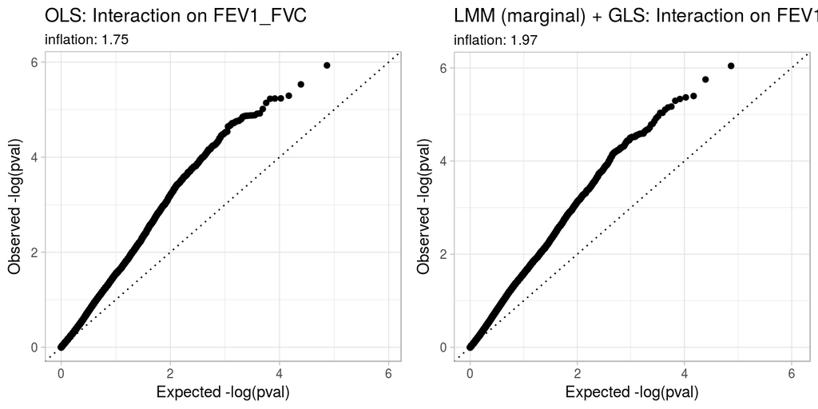

Note: the interaction term `acs_global:SmokingNow` was not included in the scan on the right panel (to be recomputed).

# 6 Interaction scan in `FEV1_FVC_utah` (interaction varcov)

The proportions of variances estimated for `FEV1_FVC_utah` trait:

$var(y) = 0.052 \Sigma_{centers} + 0.016 \sigma^2_g K + 0.005 K_d + 0.927 I$

# 7 Additional material

## 7.1 Marginal scans in other phenotypes

We do not show all QQ-plots, but we have checked that the inflation was improved in certain ways by applying the LMM1 + GLS strategy. But there are still some issues on tails of low (significant) p-values. Possible reasons might be:

- related statistics;
- proximal contamination ($K$ is estimated in all chromosomes).

### 7.1.1 `FVC_utah`

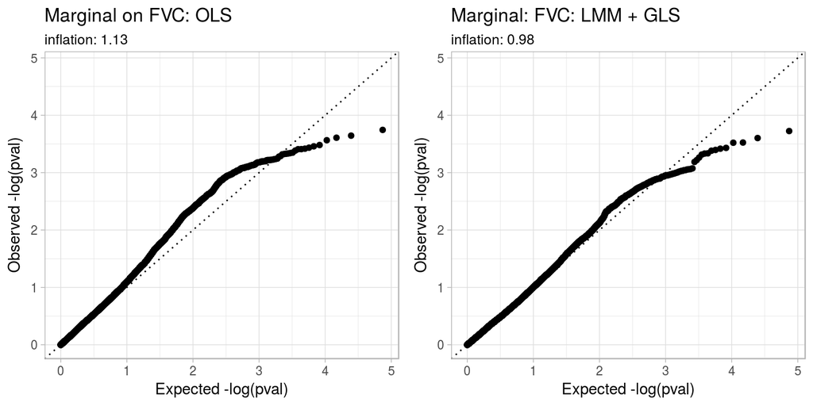

# 8 TODO

- Wait for results on marginal scans for all traits (current computations are still on-going).
- Run interaction scans for LMMs that include both $K$ and $K_d$ (interaction varcov)
  - Here, we observed that LMMs with only $K$ (marginal varcov) can not fix the inflation issue. That is consistent with results in (Sul et al. 2016).
- Implement efficient computation of scans, so permutation test are feasible.
  - Take inspiration from (Shabalin 2012).
  - Modules:
    - Project out covariates
    - Estimate p-values by computing correlation matrices
    - Store large matrices efficiently (netcf4, hdf5, big.matrix)
    - Take into account interaction tests
- Estimate permutation p-values for top signals
  - marginal signal in Chr 12
  - interaction signal in Chr 11
- Include all rather than long ancestry segments

# References

Conneely, Karen N., and Michael Boehnke. 2007. “So Many Correlated Tests, So Little Time! Rapid Adjustment of P Values for Multiple Correlated Tests.” *The American Journal of Human Genetics* 81 (6): 1158–68. doi:10.1086/522036.

Shabalin, Andrey A. 2012. “Matrix EQTL: Ultra Fast EQTL Analysis via Large Matrix Operations.” *Bioinformatics* 28 (10). Oxford Univ Press: 1353–8.

Sul, Jae Hoon, Michael Bilow, Wen-Yun Yang, Emrah Kostem, Nick Furlotte, Dan He, and Eleazar Eskin. 2016. “Accounting for Population Structure in Gene-by-Environment Interactions in Genome-Wide Association Studies Using Mixed Models.” *PLoS Genetics* 12 (3): e1005849. doi:10.1371/journal.pgen.1005849.

Zaitlen, Noah, Bogdan Pasaniuc, Sriram Sankararaman, Gaurav Bhatia, Jianqi Zhang, Alexander Gusev, Taylor Young, et al. 2014. “Leveraging population admixture to characterize the heritability of complex traits.” *Nature Genetics* 46 (12). Nature Publishing Group: 1356–62. doi:10.1038/ng.3139.